# Question : What facters affect a Borrower rate?

### Univariate Exploration

#### EmploymentStatus

We will see that most people who have a loan are employed for this plot, followed by a full-time job. On the other hand, few people have a loan that isn't employed and retired.

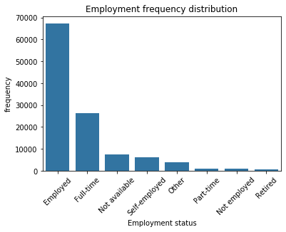

```python
base_color = sns.color_palette()[0]
freq_status = df.EmploymentStatus.value_counts()
order_status = freq_status.index
sns.countplot(x = 'EmploymentStatus', data = df, color = base_color,order = order_status)
plt.xlabel('Employment status')
plt.ylabel('frequency')
plt.title('Employment frequency distribution')
plt.xticks(rotation = 45)


plt.show()
```

#### IncomeRange

This plot shows the distribution of income range. We will see that the people who have income in the range 25k - 50k and 50l - 75k dollars are the most people who have a loan. Follow by 75k - 100k and more than 100k dollars.

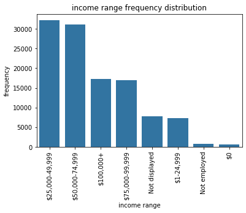

```python
income_freq = df['IncomeRange'].value_counts()
income_order = income_freq.index
sns.countplot(x = 'IncomeRange',data = df, order = income_order, color = base_color)
plt.xticks(rotation = 90)
plt.xlabel('income range')
plt.ylabel('frequency')
plt.title('income range frequency distribution')
plt.show()
```

#### Occupation

If we neglect other and professional, a programmer is the most occupation of people who have a loan. Follow by an executive, teacher, administrative, and analyst.

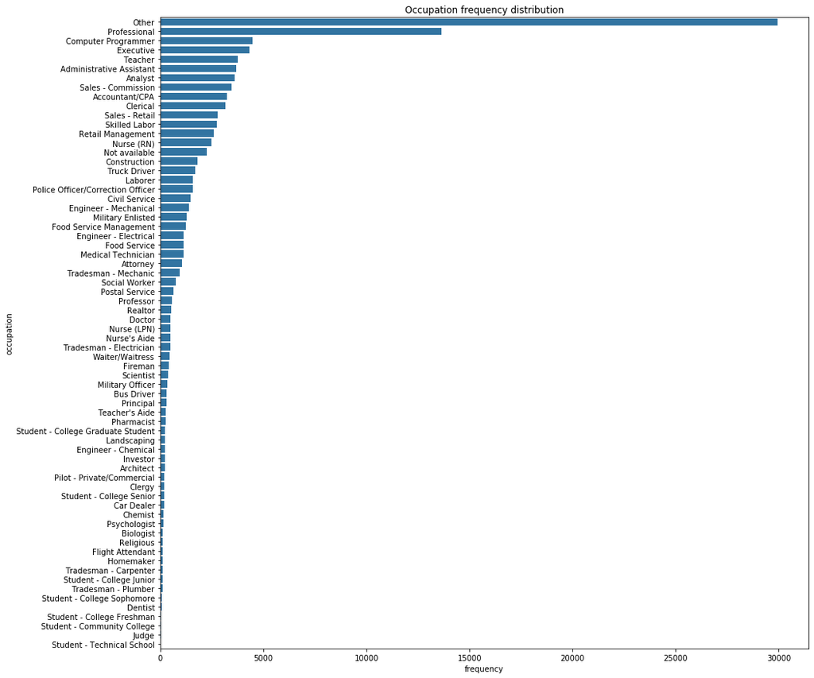

```python
occupation_freq = df['Occupation'].value_counts()
occupation_order = occupation_freq.index
plt.figure(figsize = (15,15))
sns.countplot(y = 'Occupation', data = df, order = occupation_order, color = base_color)
plt.xlabel('frequency')
plt.ylabel('occupation')
plt.title('Occupation frequency distribution')
plt.show()
```

#### EstimatedReturn

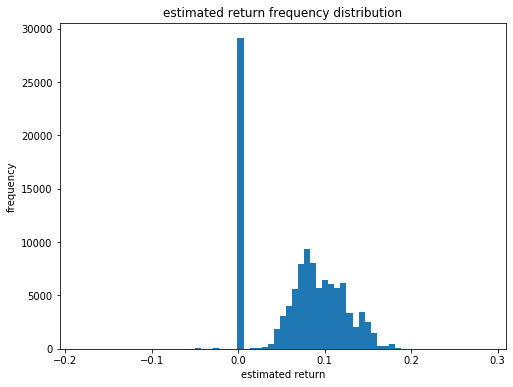

```python
bins_edge = np.arange(df.EstimatedReturn.min(),df.EstimatedReturn.max() + 0.007,0.007)
plt.figure(figsize = (8,6))
plt.hist(x = 'EstimatedReturn', data = df, bins = bins_edge)
plt.xlabel('estimated return')
plt.ylabel('frequency')
plt.title('estimated return frequency distribution');
```

The peak of the estimated return distribution graph is 0. Some points show us that the return is negative or losing. For the estimated return distribution, which greater than 0, we will see in the following graph.

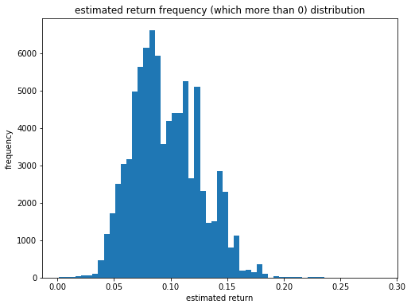

```python
bins_edge = np.arange(0.001,df.EstimatedReturn.max() + 0.005,0.005)
plt.figure(figsize = (8,6))
plt.hist(x = 'EstimatedReturn', data = df, bins = bins_edge)
plt.xlabel('estimated return')
plt.ylabel('frequency')
plt.title('estimated return frequency (which more than 0) distribution');
```

The estimated return distribution graph looked like normal distribution and peaked at around 0.07 - 0.08.

#### EstimatedLoss

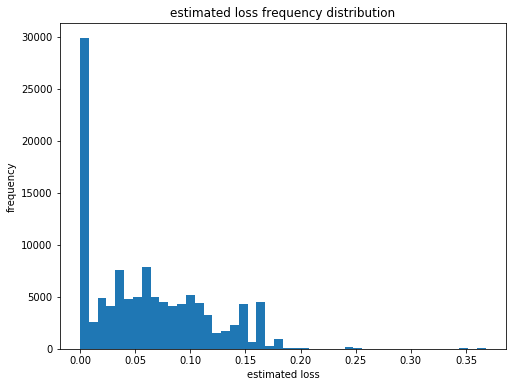

```python
bins_edge = np.arange(df.EstimatedLoss.min(),df.EstimatedLoss.max() + 0.008,0.008)
plt.figure(figsize = (8,6))
plt.hist(x = 'EstimatedLoss', data = df, bins = bins_edge)
plt.xlabel('estimated loss')
plt.ylabel('frequency')
plt.title('estimated loss frequency distribution');
```

This graph shows us that the most loss is 0 or no loss from the peak, and the next graph will show the distribution of the estimated loss that greater than 0.

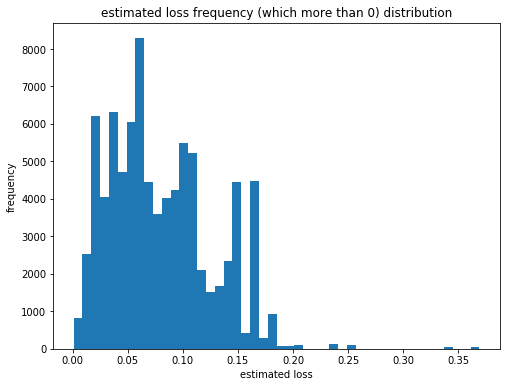

```python
bins_edge = np.arange(0.001,df.EstimatedLoss.max() + 0.008,0.008)
plt.figure(figsize = (8,6))
plt.hist(x = 'EstimatedLoss', data = df, bins = bins_edge)
plt.xlabel('estimated loss')
plt.ylabel('frequency')
plt.title('estimated loss frequency (which more than 0) distribution');
```

The peak of this graph is around 0.06 or the most estimated loss is around 6%. The graph look like right-skew distribution.

#### ProsperScore

Prosper score is defined from the customer risk score. Ten will be the best or no risk. On the other hand, 0 will be the worst or high risk. In this graph, the most score is 0, followed by 4, 6, and 8.

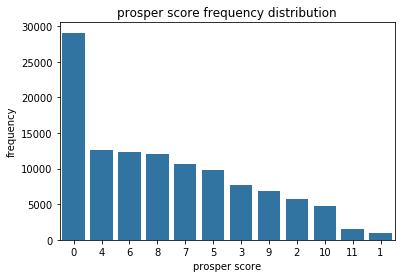

```python
score_freq = df.ProsperScore.value_counts()
sns.countplot(x = 'ProsperScore', data = df, order = score_freq.index, color = base_color)
plt.xlabel('prosper score')
plt.ylabel('frequency')
plt.title('prosper score frequency distribution');
```

#### IsBorrowerHomeowner

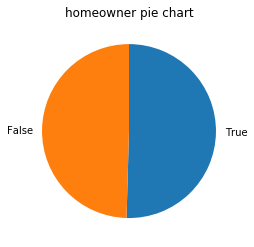

```python
homeowner = df.IsBorrowerHomeowner.value_counts()
plt.pie(x = homeowner, labels = homeowner.index, startangle=90, counterclock = False)
plt.title('homeowner pie chart');
```

#### Term

Most people's loan term is three years, followed by five years. There is sometimes that people's loan term is one year.

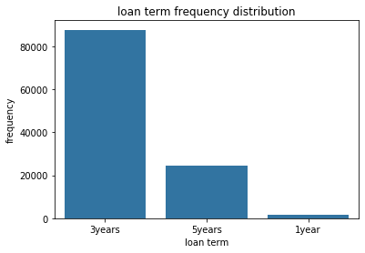

```python
term = df.Term.value_counts()
sns.countplot(x = 'Term', data = df, order = term.index, color = base_color)
plt.xlabel('loan term')
plt.ylabel('frequency')
plt.title('loan term frequency distribution');
```

#### LoanStatus

Some people completed the loan. The past due and canceled status is a bit low. Most people are on loan.

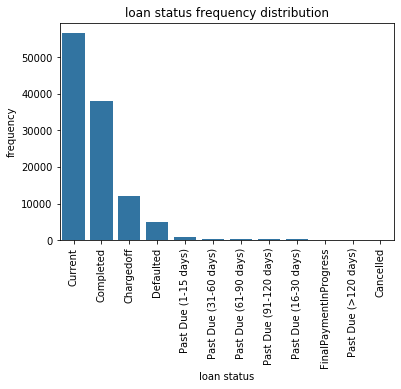

```python
loan_freq = df['LoanStatus'].value_counts()
sns.countplot(x = 'LoanStatus', data = df, order = loan_freq.index, color = base_color)
plt.xlabel('loan status')
plt.ylabel('frequency')
plt.title('loan status frequency distribution')
plt.xticks(rotation = 90);
```

#### BorrowerRate

Borrower rate is the people's interest rate on loans. The peak is around 0.3.

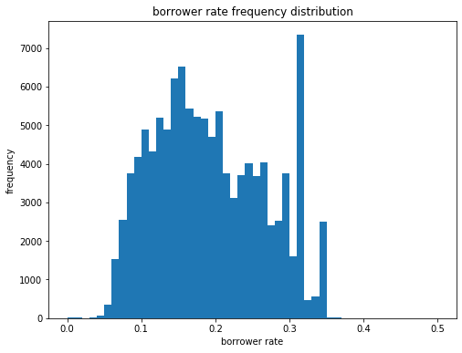

```python
bins_edge = np.arange(0,df['BorrowerRate'].max() + 0.01,0.01)
plt.figure(figsize = (8,6))
plt.hist(x = 'BorrowerRate', data = df, bins = bins_edge)
plt.xlabel('borrower rate')
plt.ylabel('frequency')
plt.title('borrower rate frequency distribution');
```

### Bivariate Exploration

#### EmploymentStatus vs BorrowerRate

From this graph, we will see that people who aren't employed have the highest median borrower rate, and this graph also tells us that it hasn't much different borrower rate between any employment status.

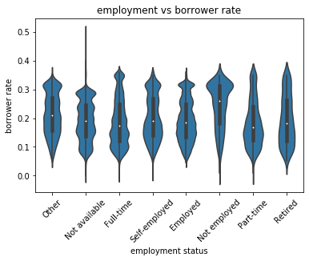

```python
sns.violinplot(x = 'EmploymentStatus', y = 'BorrowerRate', data = df, color = base_color)
plt.xlabel('employment status')
plt.ylabel('borrower rate')
plt.title('employment vs borrower rate')
plt.xticks(rotation = 45);
```

#### IncomeRange vs BorrowerRate

As same as the previous graph, the people who aren't employed have the highest median borrower rate, and it hasn't much different borrower rate between any income range.

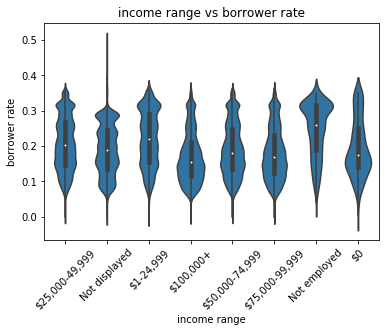

```python
sns.violinplot(x = 'IncomeRange', y = 'BorrowerRate', data = df, color = base_color)
plt.xlabel('income range')
plt.ylabel('borrower rate')
plt.title('income range vs borrower rate')
plt.xticks(rotation = 45);
```

#### Occupation vs BorrowerRate

The median borrower rate of any occupation is in the range of around 0.15 - 0.25. The occupation which has the lowest median borrower rate is a judge. For the highest is teacher's aide. The difference in borrower rate between any occupation isn't much.

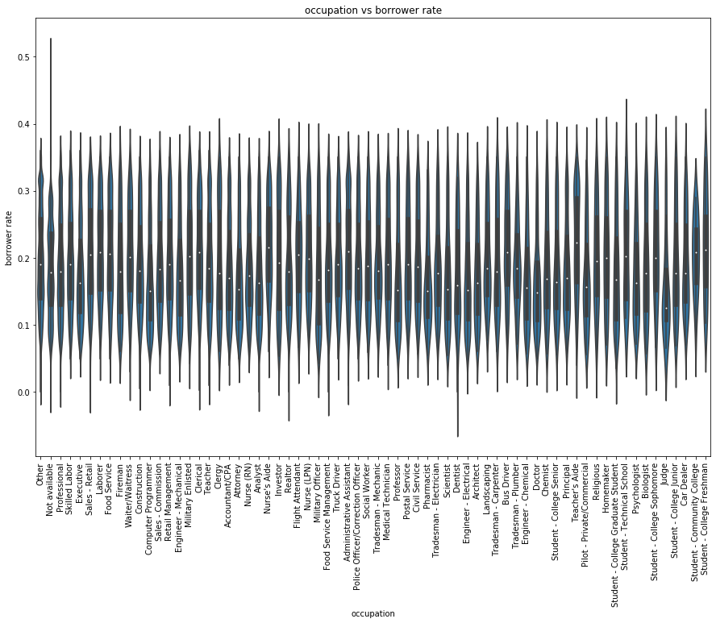

```python
plt.figure(figsize = (15,10))
sns.violinplot(x = 'Occupation', y = 'BorrowerRate', data = df, color = base_color)
plt.xlabel('occupation')
plt.ylabel('borrower rate')
plt.title('occupation vs borrower rate')
plt.xticks(rotation = 90);
```

#### EstimatedReturn vs Term

The term of a loan can affect to estimated return, the estimated return can have zero and negative only three years, and the majority is zero. For one year and five years, the estimated return is only positive.

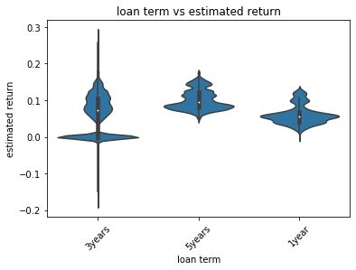

```python
sns.violinplot(x = 'Term', y = 'EstimatedReturn', data = df, color = base_color)
plt.xlabel('loan term')
plt.ylabel('estimated return')
plt.title('loan term vs estimated return')
plt.xticks(rotation = 45);
```

#### EstimatedLoss vs Term

The majority of people who have three years loan term have estimated loss is 0 and have th lowest median estimated loss.

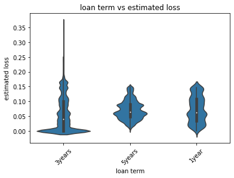

```python
sns.violinplot(x = 'Term', y = 'EstimatedLoss', data = df, color = base_color)
plt.xlabel('loan term')
plt.ylabel('estimated loss')
plt.title('loan term vs estimated loss')
plt.xticks(rotation = 45);
```

#### EstimatedReturn vs BorrowerRate

The correlation between estimated return and borrower rate is positive from this graph, so the estimated return affects the borrower rate.

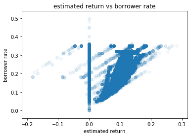

```python
sns.regplot(x = 'EstimatedReturn', y = 'BorrowerRate', data = df, fit_reg = False,
           scatter_kws = {'alpha' : 1/20})
plt.xlabel('estimated return')
plt.ylabel('borrower rate')
plt.title('estimated return vs borrower rate');
```

#### EstimatedLoss vs BorrowerRate

From this graph, the correlation between estimated loss is positive if the estimated loss is in a range of around 0 - 0.20. For the estimated loss that more than 0.2, there are no correlation between them.

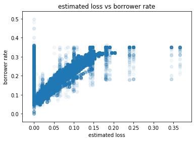

```python
sns.regplot(x = 'EstimatedLoss', y = 'BorrowerRate', data = df, fit_reg = False,
           scatter_kws = {'alpha' : 1/20})
plt.xlabel('estimated loss')
plt.ylabel('borrower rate')
plt.title('estimated loss vs borrower rate');
```

#### ProsperScore vs BorrowerRate

Except the prosper score which is zero, the higher prosper score will have lower median borrower rate.

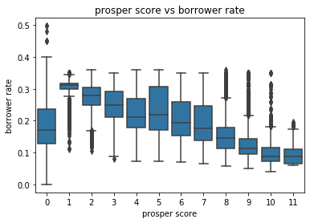

```python
sns.boxplot(x = 'ProsperScore', y = 'BorrowerRate', data = df, color = base_color)
plt.xlabel('prosper score')
plt.ylabel('borrower rate')
plt.title('prosper score vs borrower rate');
```

#### LoanStatus vs BorrowerRate

It hasn't much different borrower rate between any loan status.

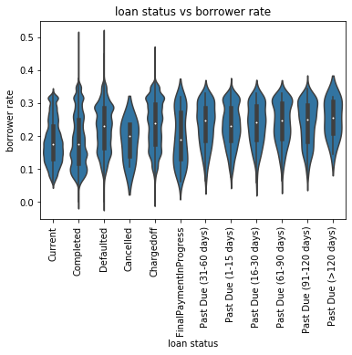

```python
sns.violinplot(x = 'LoanStatus', y = 'BorrowerRate', data = df, color = base_color)
plt.xlabel('loan status')
plt.ylabel('borrower rate')
plt.title('loan status vs borrower rate')
plt.xticks(rotation = 90);
```

### Multivariate Exploration

#### IncomeRange vs BorrowerRate vs IsBorrowerHomeowner

Borrowers who are homeowners affect the lower median borrower rate for any income range except those who aren't employed. The homeowners who aren't employed have a higher median borrower rate than those who aren't homeowners.

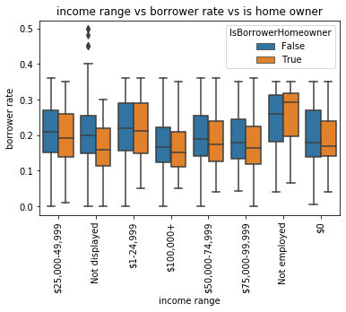

```python
sns.boxplot(x = 'IncomeRange', y = 'BorrowerRate', hue = 'IsBorrowerHomeowner',data=df)
plt.xlabel('income range')
plt.ylabel('borrower rate')
plt.title('income range vs borrower rate vs is home owner')
plt.xticks(rotation = 90);
```

#### EmploymentStatus vs BorrowerRate vs IsBorrowerHomeowner

As same as the previous graph, Borrowers who are homeowners affect the lower median borrower rate for any employment status except those who aren't employed. The homeowners who aren't employed have a higher median borrower rate than those who aren't homeowners.

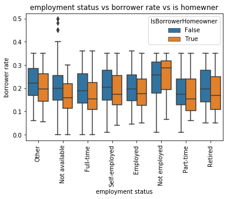

```python
sns.boxplot(x = 'EmploymentStatus', y = 'BorrowerRate', hue = 'IsBorrowerHomeowner',data=df)
plt.xlabel('employment status')
plt.ylabel('borrower rate')
plt.title('employment status vs borrower rate vs is homewner')
plt.xticks(rotation = 90);
```

## Summary

### The factors which affects the borrower rate are following :

- estimated return The increasing borrower rate follows by increasing estimated return, and correlation is a plus.
- estimated loss From correlation between estimated loss is positive if the estimated loss is in a range of around 0 - 0.20 so is the estimated loss increase in a range of around 0 - 0.2, the borrower rate increase.
- prosper score Except for the prosper score, which is zero, the increasing prosper score affects decreasing borrower rate.
- homeowner Borrowers who are homeowners affect the lower borrower rate for any income range and employment statys except those who aren't employed. The homeowners who aren't employed have a higher borrower rate than those who aren't homeowners.

### Another insights

- The people who have income in the range 25k - 50k and 50k - 75k dollars are the most people who have a loan. Follow by 75k - 100k and more than 100k dollars.
- The term of a loan can affect to estimated return, the estimated return can have zero and negative only three years, and the majority is zero. For one year and five years, the estimated return is only positive.